# Лабораторная работа № 4

Линейная алгебра в Julia

Ведьмина Александра Сергеевна

1132236003@rudn.ru

Российский университет дружбы народов

2026-10-10

## Содержание

- цель и задачи;
- окружение и `DrWatson`;
- примеры линейной алгебры;
- факторизации и структуры;
- решение СЛАУ;
- диагонализация и корни;
- модели экономики;
- Jupyter, Quarto и результаты.

# Информация

## Докладчик

- Ведьмина Александра Сергеевна;
- студентка;
- кафедра теории вероятностей и кибербезопасности;
- Российский университет дружбы народов;
- 1132236003@rudn.ru.

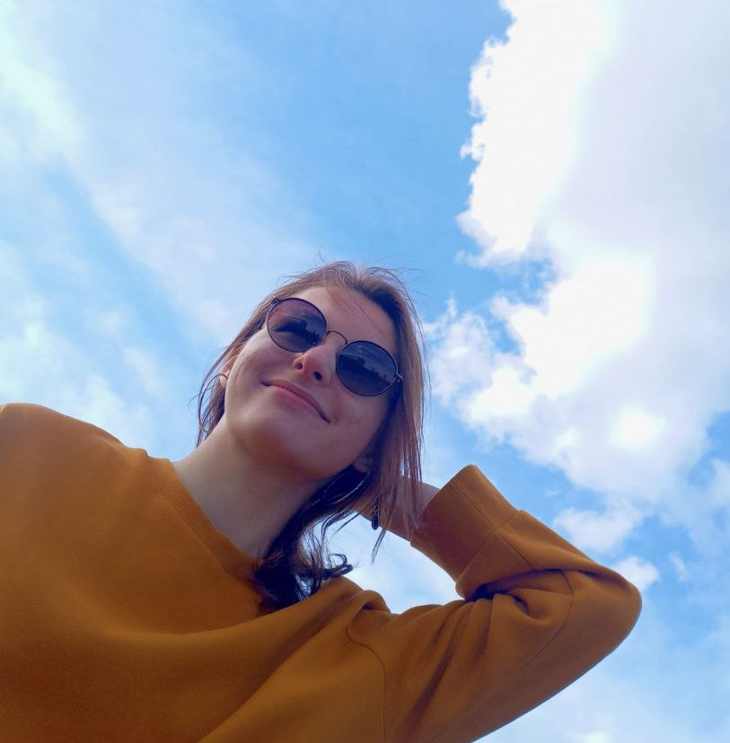

# Вводная часть

## Цель и задачи

**Цель:** изучить возможности Julia для операций линейной алгебры и оценки их эффективности.

**Задачи:**

- повторить примеры раздела 4.2;
- выполнить задания раздела 4.4;
- решить и классифицировать СЛАУ;
- исследовать факторизации и специальные матрицы;
- проверить продуктивность экономических моделей;
- сформировать воспроизводимые материалы.

## Использованные средства

| Средство | Назначение |
| --- | --- |
| Julia 1.12.5 | вычисления |
| `LinearAlgebra` | матрицы и факторизации |
| `Statistics` | средние значения |
| `BenchmarkTools` | измерение времени |
| `DrWatson` | структура проекта |
| Jupyter + IJulia | интерактивный Notebook |
| Literate + Quarto | производные форматы |

# Подготовка окружения

## Проверка программ

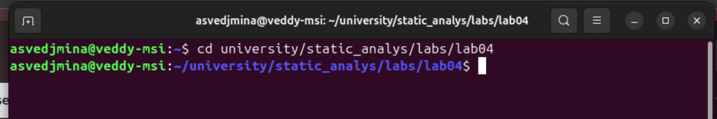

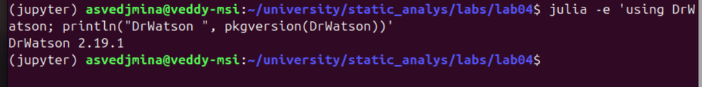

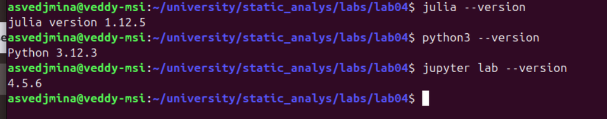

- Julia `1.12.5`;
- Jupyter Lab `4.5.6`;
- DrWatson `2.19.1`.

## Создание проекта `DrWatson`

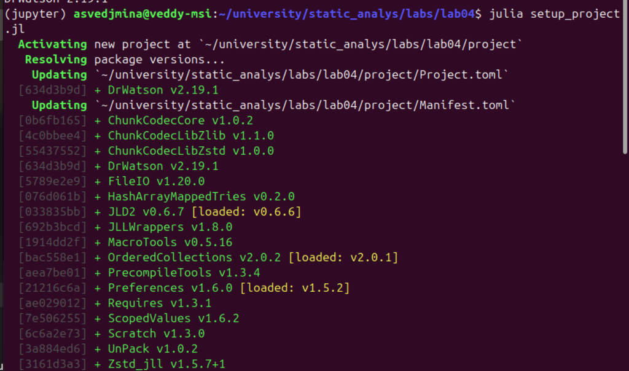

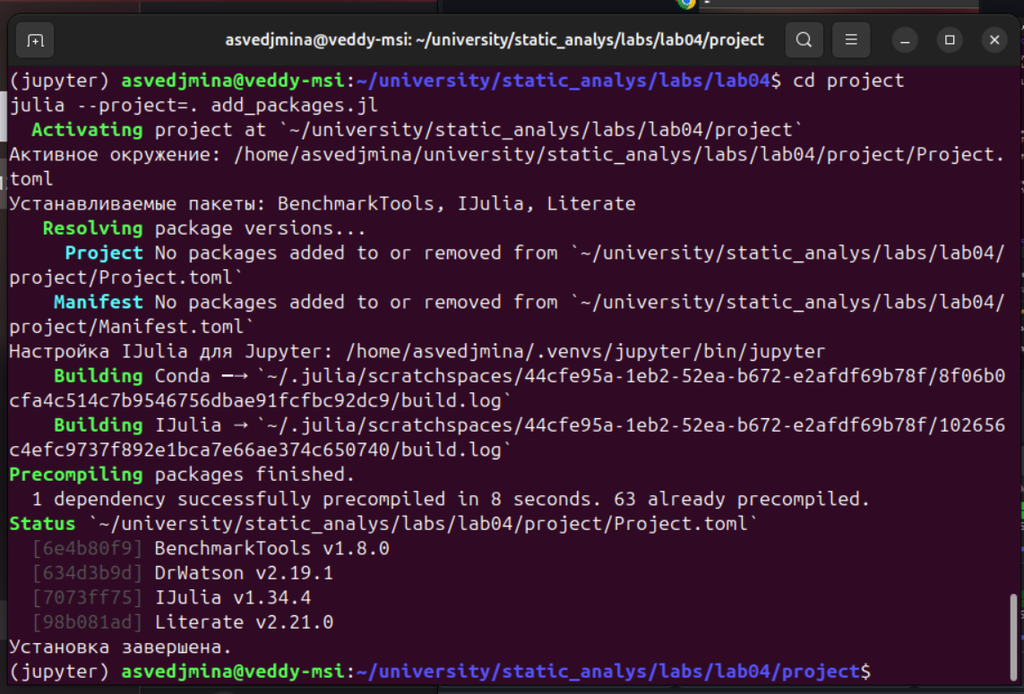

```julia
initialize_project(
    PROJECT_DIRECTORY;
    authors=["Ведьмина Александра Сергеевна"],
    git=false,
)
```

## Проверка окружения

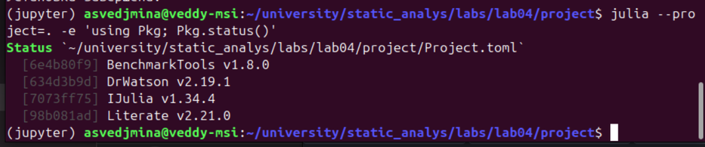

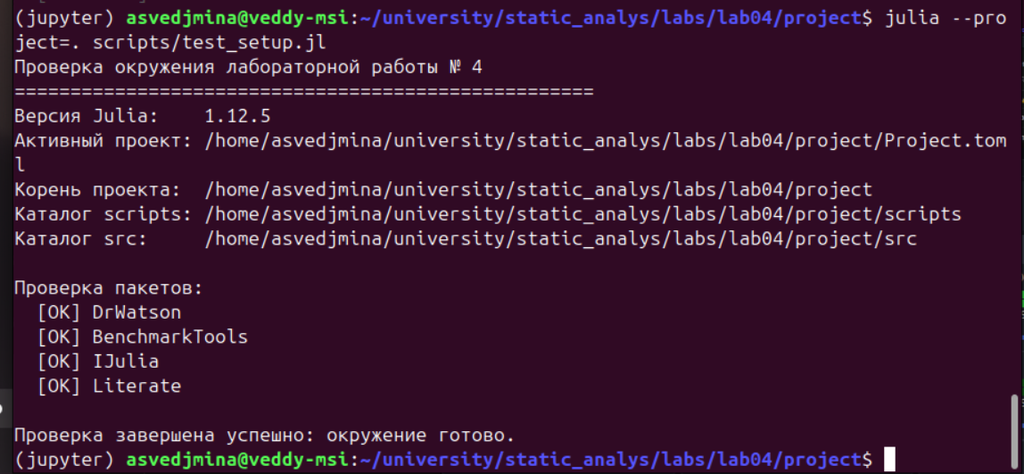

[figure not shown]

- активирован локальный `Project.toml`;
- доступны четыре внешних пакета;
- проверены пути `scripts/` и `src/`.

# Примеры раздела 4.2

## Поэлементные операции

```julia
sum(a)
sum(a; dims=1)
sum(a; dims=2)

prod(a)
prod(a; dims=1)
prod(a; dims=2)

mean(a)
mean(a; dims=1)
mean(a; dims=2)
```

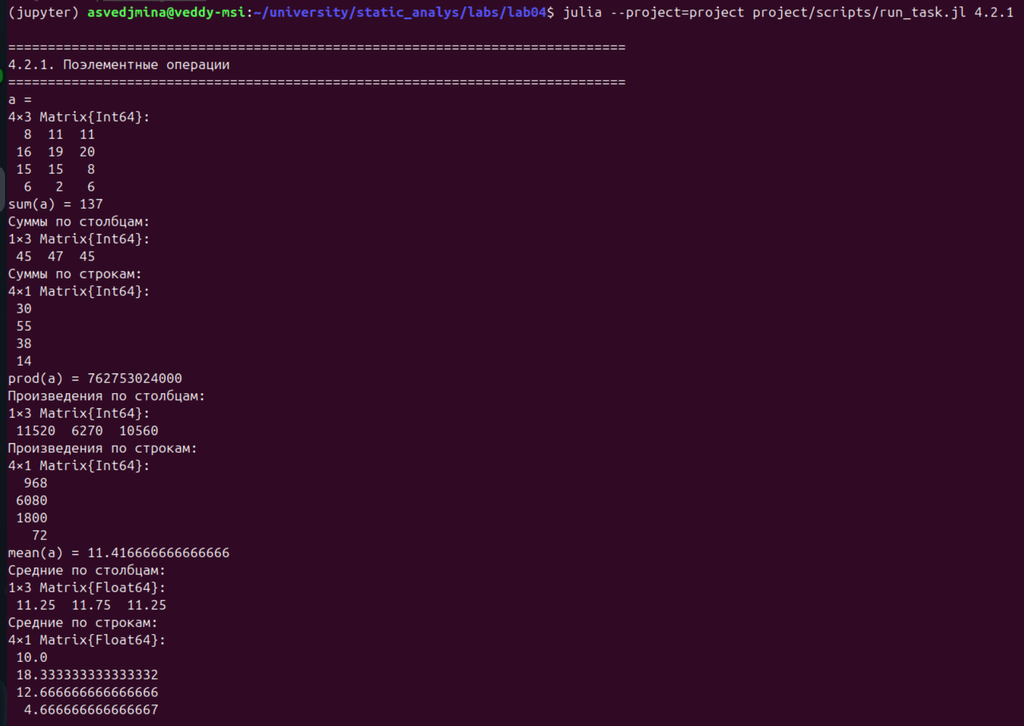

| Показатель | Результат |
| --- | --- |
| сумма | 137 |
| произведение | 762753024000 |
| среднее | 11,4167 |

## Основные матричные операции

```julia
transpose(b)
tr(b)
diag(b)
rank(b)
inv(b)
det(b)
pinv(a)
```

- $\operatorname{tr}b=49$;
- $\operatorname{rank}b=4$;
- $\det b\approx11228$.

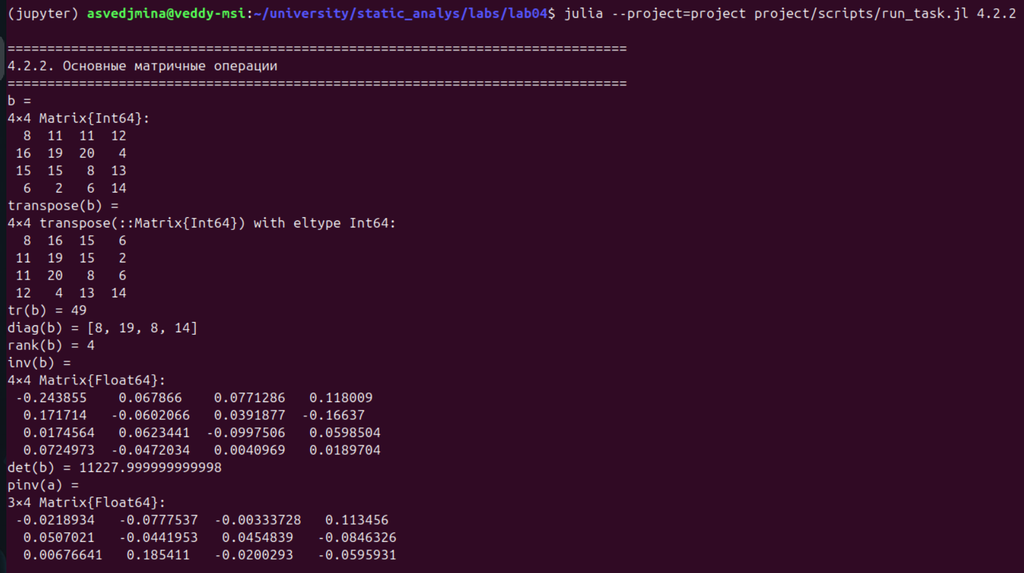

## Нормы и повороты

$$\lVert X-Y\rVert_2=9{,}4868,
\qquad
\varphi=2{,}4404.$$

```julia
norm(X)
norm(X - Y)
opnorm(d)
rot180(d)
reverse(d; dims=1)
reverse(d; dims=2)
```

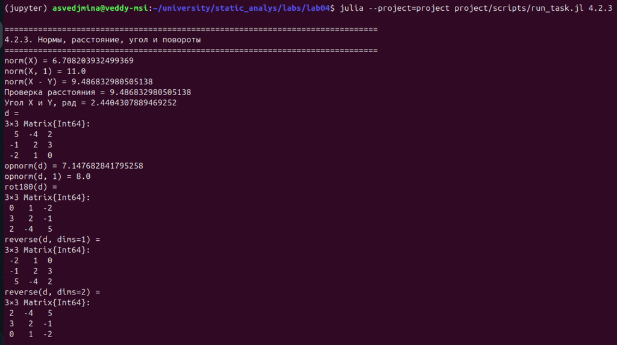

## Матричное умножение

```julia
A_product * B_product

Matrix{Int}(I, 3, 3)

dot(X, Y)
X'Y
```

Оба способа вычисления скалярного произведения дали

$$X^TY=-17.$$

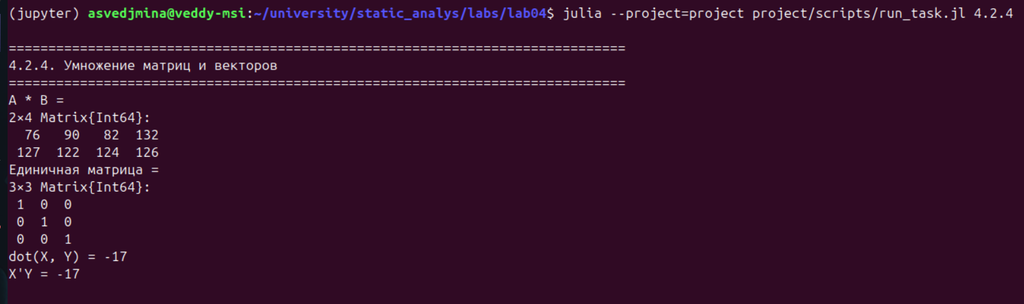

## Факторизации

```julia
A_lu = lu(A)
A_lu.P
A_lu.L
A_lu.U

A_qr = qr(A)
Q = Matrix(A_qr.Q)
R = A_qr.R

eigen(Symmetric(A + A'))
```

Проверены:

- $PA\approx LU$;
- $Q^TQ\approx I$;
- $QR\approx A$.

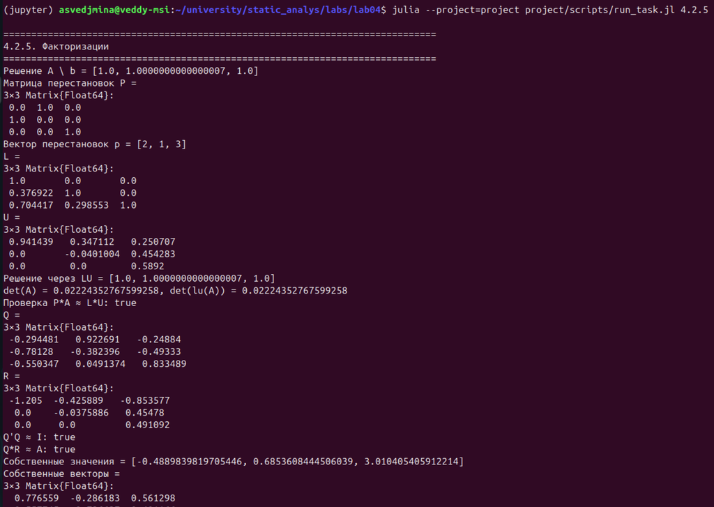

## Структурированные матрицы

| Представление $1000\times1000$ | `eigvals`, с |
| --- | --- |
| симметричная | 0,0654 |
| зашумлённая общего вида | 0,4229 |
| явная `Symmetric` | 0,0656 |

- `Symmetric` сохраняет быстрый алгоритм;
- `SymTridiagonal` размера $10^6\times10^6$ обработана без плотной копии;
- плотной матрице потребовалось бы около 7,28 ТиБ памяти.

## Рациональная линейная алгебра

```julia
A_rational =
    Rational{BigInt}.(
        rand(1:10, 3, 3),
    ) ./ 10

b = A_rational * ones(BigInt, 3)

A_rational \ b
lu(A_rational)
```

Точное решение:

$$x=(1,1,1)^T.$$

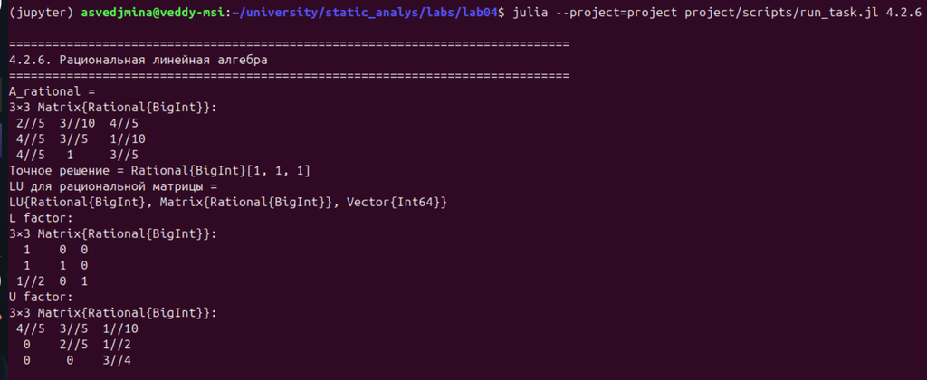

# Самостоятельные задания

## Произведение векторов

```julia
v = [1, 2, 3]
dot_v = dot(v, v)
outer_v = v * v'
```

$$v^Tv=14,
\qquad
vv^T=
\begin{pmatrix}
1&2&3\\
2&4&6\\
3&6&9
\end{pmatrix}.$$

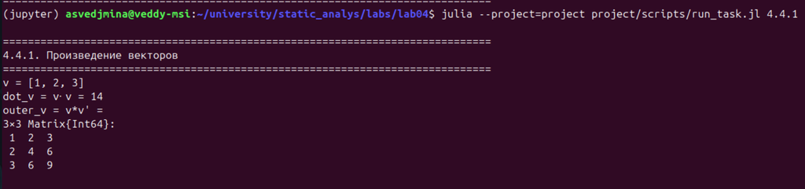

## СЛАУ с двумя неизвестными

| Система | Тип | Решение |
| --- | --- | --- |
| a | одна | $(5/2,-1/2)$ |
| b | $\infty$ | $(2,0)+t(-1,1)$ |
| c | нет | — |
| d | $\infty$ | $(1,0)+t(-1,1)$ |
| e | нет | — |
| f | одна | $(-1,3)$ |

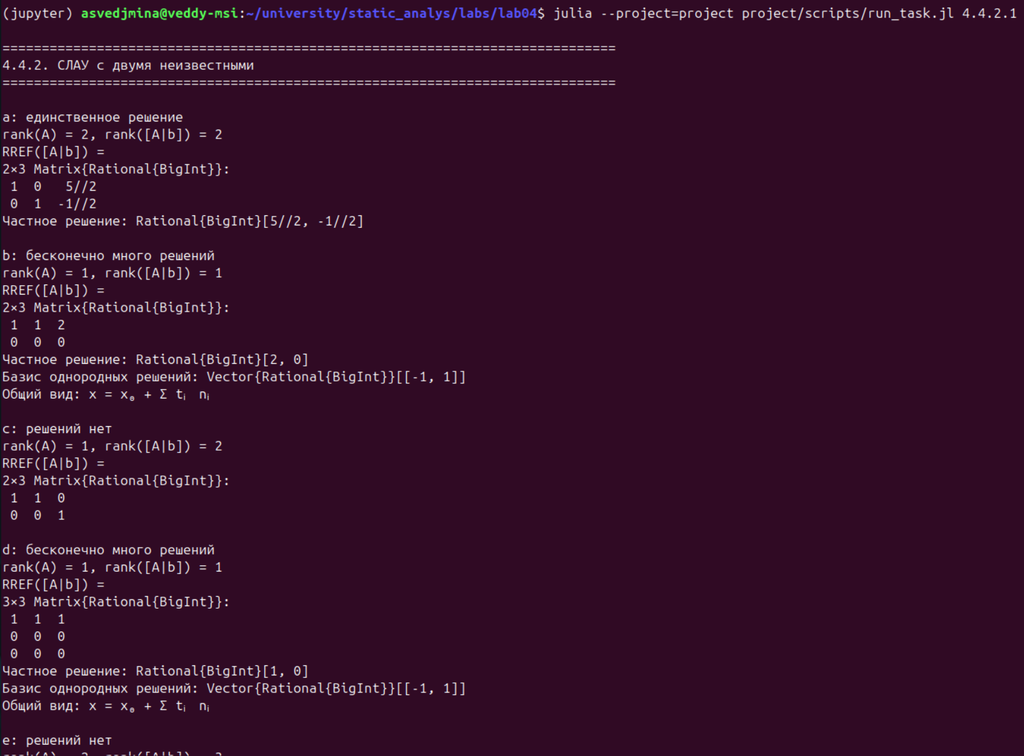

## СЛАУ с тремя неизвестными

| Система | Тип | Частное решение |
| --- | --- | --- |
| a | $\infty$ | $(5/2,-1/2,0)$ |
| b | одна | $(-1/2,5/2,0)$ |
| c | $\infty$ | $(2,0,-1)$ |
| d | нет | — |

Для свободных переменных построен базис ядра матрицы коэффициентов.

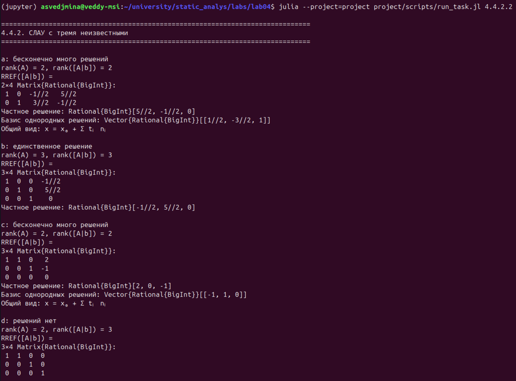

## Диагонализация

```julia
decomposition = eigen(
    Symmetric(Float64.(A)),
)
D = Diagonal(
    decomposition.values,
)
P = decomposition.vectors

norm(A * P - P * D)
```

Невязки: от $0$ до $7{,}18\cdot10^{-15}$.

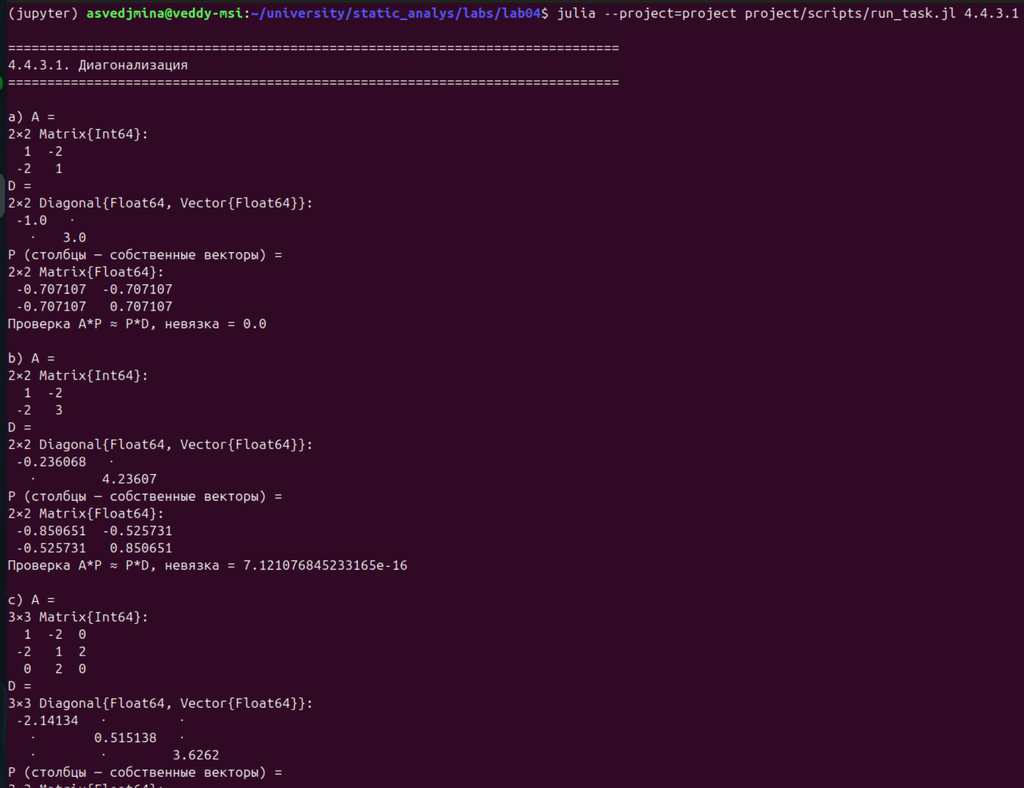

## Степень и корни матриц

| Пункт | Проверка |
| --- | --- |
| a | $A^{10}$ вычислена точно |
| b | $R^2\approx A$ |
| c | $R^3\approx A$ |
| d | $R^2\approx A$ |

```julia
R = P * Diagonal(
    f.(values),
) * P'
```

В пункте d корень комплексный из-за отрицательного собственного значения.

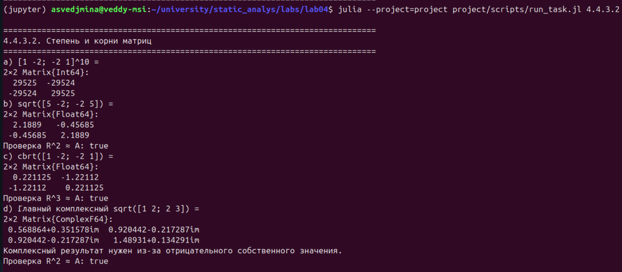

## Собственные значения и время

| $i$ | $\lambda_i$ |
| --- | --- |
| 1 | $-128{,}493$ |
| 2 | $-55{,}888$ |
| 3 | $42{,}752$ |
| 4 | $87{,}161$ |
| 5 | $542{,}468$ |

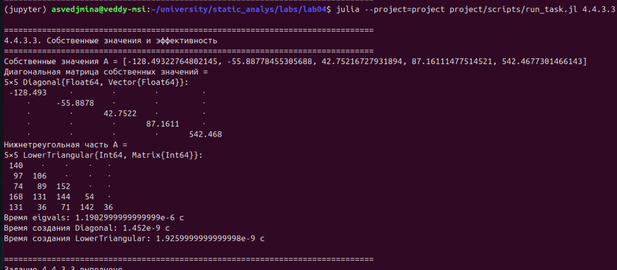

# Линейные модели экономики

## Проверка по определению

$$x=(I-A)^{-1}y.$$

| Пункт | Результат |
| --- | --- |
| a | непродуктивна |
| b | непродуктивна |
| c | продуктивна |

Для a и b найдены $y\geq0$ с отрицательным элементом решения $x$.

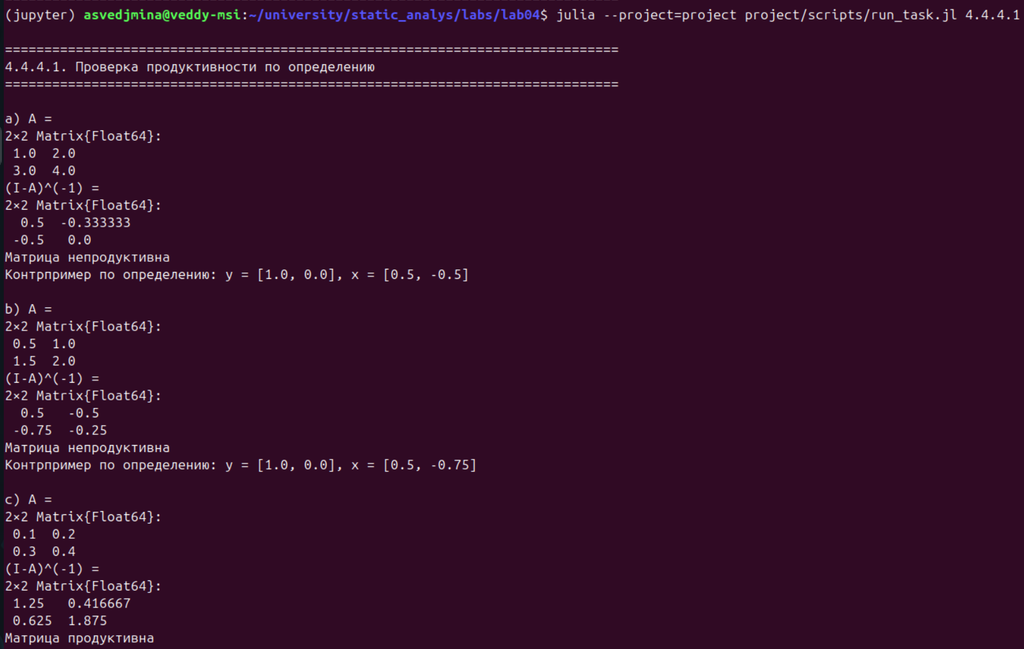

## Критерий $(I-A)^{-1}\geq0$

```julia
leontief_inverse = inv(I - A)
productive = all(
    value -> value >= -1e-12,
    leontief_inverse,
)
```

| Пункт | Результат |
| --- | --- |
| a | непродуктивна |
| b | непродуктивна |
| c | продуктивна |

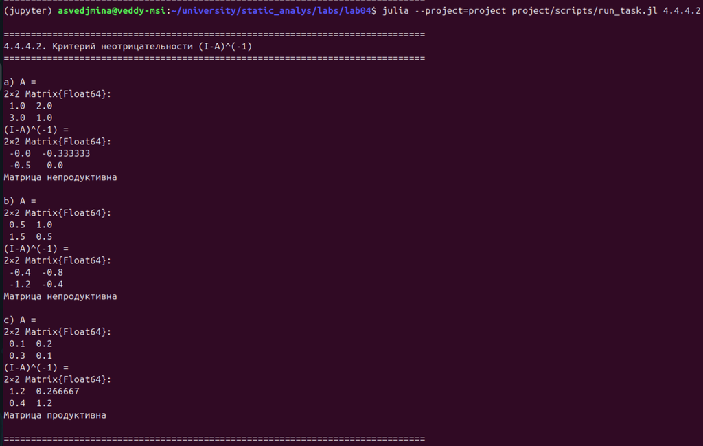

## Спектральный критерий

```julia
values = eigvals(A)
radius = maximum(abs.(values))
productive = radius < 1
```

| Пункт | $\rho(A)$ | Результат |
| --- | --- | --- |
| a | 3,449 | нет |
| b | 1,725 | нет |
| c | 0,345 | да |
| d | 0,373 | да |

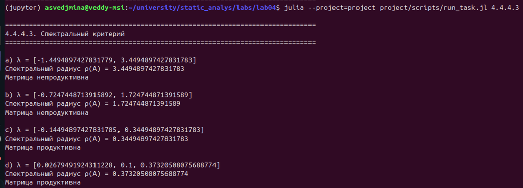

# Воспроизводимые результаты

## Генерация полного комплекта

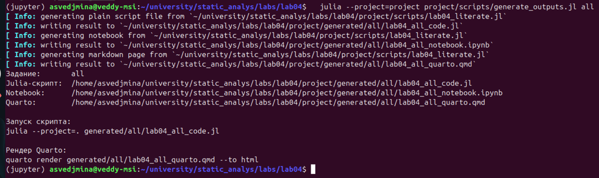

Для каждого задания созданы:

- Julia-сценарий `_code.jl`;
- Notebook `_notebook.ipynb`;
- Quarto-источник `_quarto.qmd`;
- итоговый `_quarto.html`.

## Отдельные задания

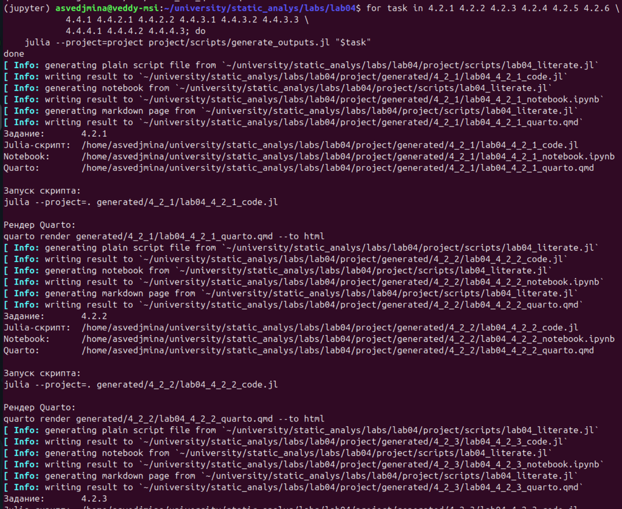

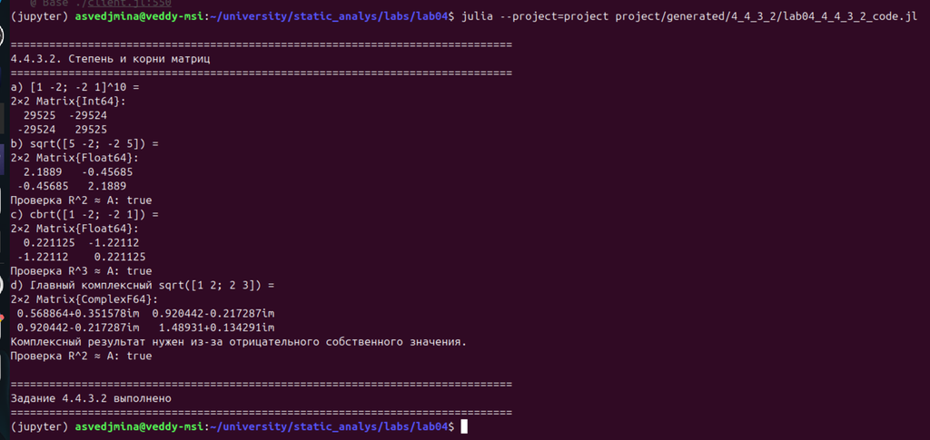

**Результат:** 15 селекторов, комплект `all` и единый исходный код.

## Выполненный Notebook: исходный код

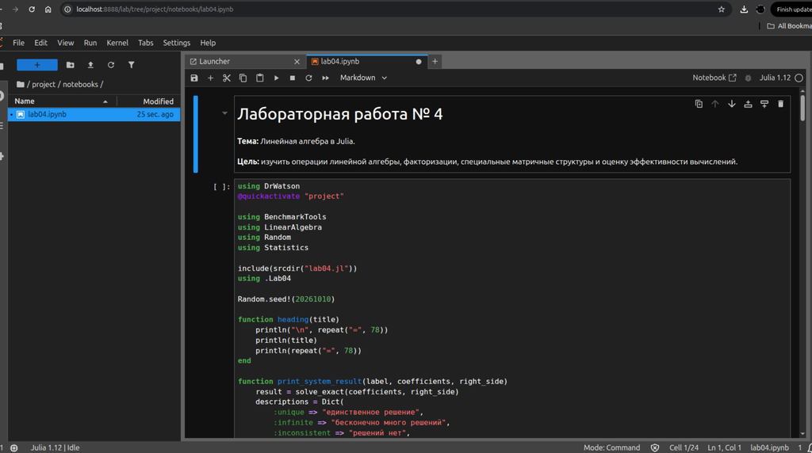

- код и пояснения находятся в одном документе;
- активировано локальное окружение DrWatson;
- определения функций отделены от их вызовов.

## Выполненный Notebook: результаты

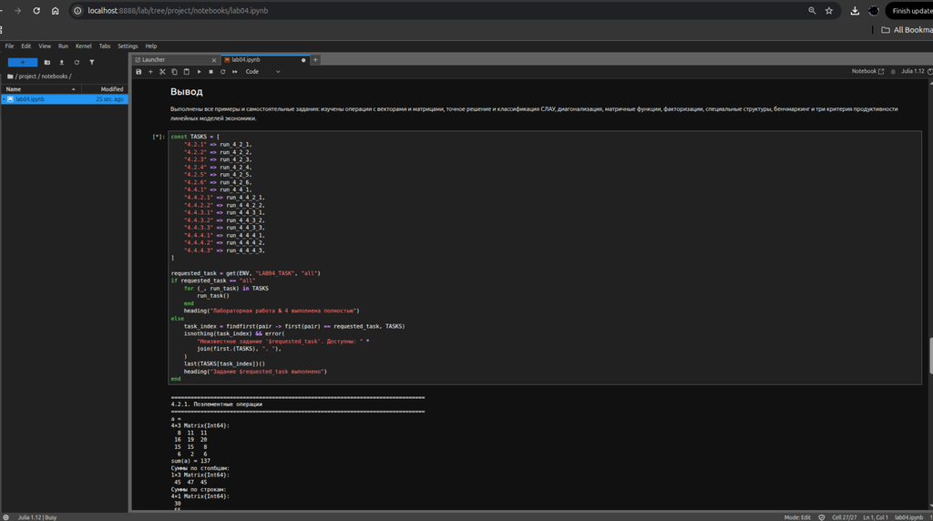

- выполнены все кодовые ячейки;
- сохранены матрицы, таблицы и диагностические проверки;
- выводов с типом `error` нет.

## Quarto и итоговая проверка

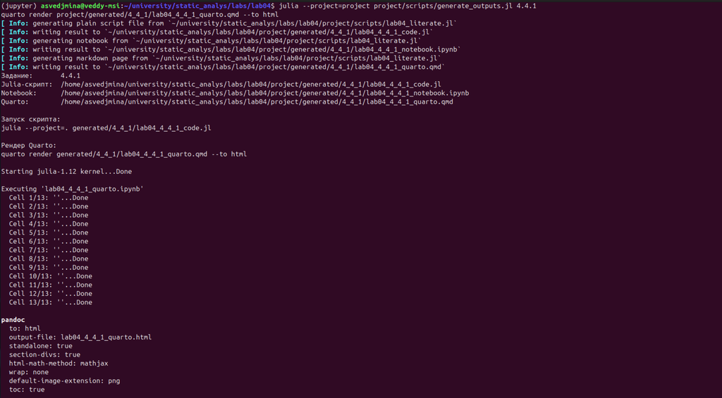

| Материал | Число |
| --- | --- |
| Julia-сценарии | 16 |
| Notebook заданий | 16 |
| основной Notebook | 1 |
| QMD | 16 |
| HTML | 16 |
| тесты | 14 |

Все Notebook и Quarto-документы выполнены без ошибок.

# Выводы

## Итоги работы

- освоены операции `LinearAlgebra` и `Statistics`;
- выполнены LU-, QR- и спектральное разложения;
- точно решены и классифицированы десять СЛАУ;
- выполнены диагонализация, матричные степени и корни;
- проверена продуктивность моделей тремя критериями;
- показано преимущество структурированных матриц;
- сформированы 16 воспроизводимых комплектов материалов;
- все 17 Notebook, 16 Quarto HTML и 14 тестов выполнены без ошибок.

**Цель лабораторной работы достигнута.**